```python
import pandas as pd
import numpy as np
from sklearn.utils import shuffle
import numpy as np
from wordcloud import WordCloud as wcl
from wordcloud import STOPWORDS
import matplotlib.pyplot as plt
import pandas as pd
import seaborn as sns
import pandas as pd
import numpy as np
import matplotlib.pyplot as plt
import seaborn as sns
```

# Tweets

```python
import sys
print(sys.executable)
```

```
/home/ashish/anaconda3/bin/python
```

```python
df = pd.read_csv(r"1377884570_tweet_global_warming.csv", encoding ="latin-1")
```

```python
df.tail()
```

|  | tweet | existence | confidence | other1 | other2 | other3 |
| --- | --- | --- | --- | --- | --- | --- |
| 6085 | @bloodless_coup "The phrase 'global warming' s... | Y | 1 | NaN | NaN | NaN |
| 6086 | Virginia to Investigate Global Warming Scienti... | NaN | 1 | NaN | NaN | NaN |
| 6087 | Global warming you tube parody you will enjoy ... | N | 0.6411 | NaN | NaN | NaN |
| 6088 | One-Eyed Golfer: Don't dare tell me about glob... | N | 1 | NaN | NaN | NaN |
| 6089 | man made global warming a hair brained theory ... | N | 1 | NaN | NaN | NaN |

```python
df=df.replace(to_replace ="Y", value ="Yes")
```

```python
df=df.replace(to_replace ="N", value ="No")
```

```python
y1 = df[df.existence == 'Yes']
```

```python
n1 = df[df.existence =='No']
```

```python
n2 = df[df.existence =='NA']
```

```python
y1.tail()
```

|  | tweet | existence | confidence | other1 | other2 | other3 |
| --- | --- | --- | --- | --- | --- | --- |
| 6080 | Bats, Birds and Lizards Can Fight Climate Chan... | Yes | 0.6751 | NaN | NaN | NaN |
| 6081 | Bats, Birds and Lizards Can Fight Climate Chan... | Yes | 1 | NaN | NaN | NaN |
| 6082 | Global warming: The fossil fuel dilemma: Ameri... | Yes | 1 | NaN | NaN | NaN |
| 6084 | It's 83ï¿½_ï¿½ and climbing in NYC. August wea... | Yes | 1 | NaN | NaN | NaN |
| 6085 | @bloodless_coup "The phrase 'global warming' s... | Yes | 1 | NaN | NaN | NaN |

```python
d1=pd.concat([y1,n1])
df=pd.concat([d1,n2])
```

```python
def word_cloud(words):
    stopwords = set(STOPWORDS)
    wordcloud = wcl(max_words=204,width = 603, height = 603,background_color ='black', stopwords = stopwords,
                min_font_size = 10).generate(words)

    plt.figure(figsize = (9, 9), facecolor = None)
    plt.imshow(wordcloud)
    plt.axis("off")
    plt.tight_layout(pad = 0)
    plt.show()
```

```python
def extract_words(tweets):
    distinct_words = ' '
    for tweet in tweets:
        tweet = str(tweet)
        tokens = tweet.split()
        for i in range(len(tokens)):
            tokens[i] = tokens[i].lower()
        for words in tokens:
            distinct_words = distinct_words + words + ' '
    return distinct_words
```

```python
unique_wrds = extract_words(df.tweet)
```

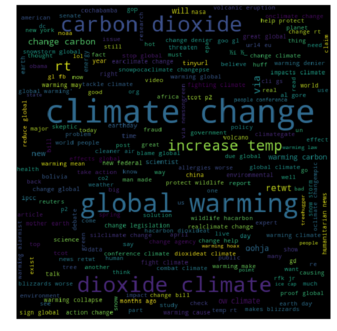

```python
word_cloud(unique_wrds)
```

From Tweets we can infer that increase in carbon dioxide leads to increase in temperature which is responsible for awareness among people about global warming.

# Co2 Emmision

```python
co2 = pd.read_csv("./data/CO2 emissions per capita per country.csv")
```

Unit metric

```python
co2.head(130)
```

|  | Country Name | Country Code | 1960 | 1961 | 1962 | 1963 | 1964 | 1965 | 1966 | 1967 | ... | 2005 | 2006 | 2007 | 2008 | 2009 | 2010 | 2011 | 2012 | 2013 | 2014 |
| --- | --- | --- | --- | --- | --- | --- | --- | --- | --- | --- | --- | --- | --- | --- | --- | --- | --- | --- | --- | --- | --- |
| 0 | Aruba | ABW | NaN | NaN | NaN | NaN | NaN | NaN | NaN | NaN | ... | 27.200708 | 26.948260 | 27.895574 | 26.230847 | 25.915833 | 24.670529 | 24.505835 | 13.155542 | 8.351294 | 8.408363 |
| 1 | Afghanistan | AFG | 0.046060 | 0.053604 | 0.073765 | 0.074233 | 0.086292 | 0.101467 | 0.107637 | 0.123734 | ... | 0.052948 | 0.063728 | 0.085418 | 0.154101 | 0.241723 | 0.293837 | 0.412017 | 0.350371 | 0.315602 | 0.299445 |
| 2 | Angola | AGO | 0.097472 | 0.079038 | 0.201289 | 0.192535 | 0.201003 | 0.191528 | 0.246413 | 0.154912 | ... | 0.979740 | 1.098884 | 1.197844 | 1.181527 | 1.232495 | 1.243406 | 1.252789 | 1.330843 | 1.254617 | 1.291328 |
| 3 | Albania | ALB | 1.258195 | 1.374186 | 1.439956 | 1.181681 | 1.111742 | 1.166099 | 1.333055 | 1.363746 | ... | 1.412498 | 1.302576 | 1.322335 | 1.484311 | 1.495600 | 1.578574 | 1.803715 | 1.692908 | 1.749211 | 1.978763 |
| 4 | Andorra | AND | NaN | NaN | NaN | NaN | NaN | NaN | NaN | NaN | ... | 7.299872 | 6.746219 | 6.519466 | 6.427887 | 6.121652 | 6.122595 | 5.867130 | 5.916597 | 5.900753 | 5.832170 |
| 5 | Arab World | ARB | 0.643689 | 0.685151 | 0.760855 | 0.874941 | 0.999098 | 1.165705 | 1.272651 | 1.331404 | ... | 4.168486 | 4.268240 | 4.100226 | 4.390401 | 4.542151 | 4.615758 | 4.537755 | 4.813631 | 4.650474 | 4.860234 |
| 6 | United Arab Emirates | ARE | 0.118758 | 0.108837 | 0.163018 | 0.175223 | 0.132355 | 0.146327 | 0.159950 | 5.383685 | ... | 25.362373 | 23.631089 | 22.439801 | 22.823947 | 21.908556 | 19.443690 | 19.076489 | 19.817684 | 18.954164 | 23.302023 |
| 7 | Argentina | ARG | 2.367473 | 2.442616 | 2.522392 | 2.316356 | 2.538379 | 2.641714 | 2.792654 | 2.858162 | ... | 4.141237 | 4.434821 | 4.382669 | 4.682912 | 4.410890 | 4.558500 | 4.600291 | 4.569384 | 4.462904 | 4.746797 |
| 8 | Armenia | ARM | NaN | NaN | NaN | NaN | NaN | NaN | NaN | NaN | ... | 1.460030 | 1.481178 | 1.726570 | 1.911538 | 1.509412 | 1.465622 | 1.710071 | 1.976060 | 1.899712 | 1.902759 |
| 9 | American Samoa | ASM | NaN | NaN | NaN | NaN | NaN | NaN | NaN | NaN | ... | NaN | NaN | NaN | NaN | NaN | NaN | NaN | NaN | NaN | NaN |
| 10 | Antigua and Barbuda | ATG | 0.662643 | 0.849084 | 1.796794 | 1.446821 | 1.540135 | 2.473585 | 5.613448 | 8.912847 | ... | 4.806998 | 4.913644 | 5.136473 | 5.194500 | 5.446757 | 5.539568 | 5.363407 | 5.418447 | 5.360453 | 5.377649 |
| 11 | Australia | AUS | 8.582937 | 8.641569 | 8.835688 | 9.226440 | 9.759073 | 10.622321 | 10.328092 | 10.955625 | ... | 17.169711 | 17.651398 | 17.865260 | 18.160876 | 18.200182 | 17.740845 | 17.538878 | 17.072905 | 16.095833 | 15.388766 |
| 12 | Austria | AUT | 4.373319 | 4.496362 | 4.755362 | 5.155194 | 5.391004 | 5.252197 | 5.361725 | 5.417737 | ... | 9.020170 | 8.727298 | 8.406419 | 8.295096 | 7.518751 | 8.071132 | 7.748134 | 7.387077 | 7.368748 | 6.869868 |
| 13 | Azerbaijan | AZE | NaN | NaN | NaN | NaN | NaN | NaN | NaN | NaN | ... | 4.091802 | 4.616300 | 3.555340 | 4.051383 | 3.565668 | 3.388226 | 3.646180 | 3.824877 | 3.785069 | 3.931561 |
| 14 | Burundi | BDI | NaN | NaN | 0.015207 | 0.016160 | 0.015833 | 0.011914 | 0.015121 | 0.014740 | ... | 0.020747 | 0.024366 | 0.023555 | 0.023219 | 0.022462 | 0.024260 | 0.026762 | 0.030297 | 0.030176 | 0.044485 |
| 15 | Belgium | BEL | 9.941594 | 10.103872 | 10.641190 | 11.386929 | 11.053655 | 11.141656 | 11.042019 | 11.217257 | ... | 10.355393 | 10.151039 | 9.744777 | 9.751985 | 9.249616 | 10.171465 | 9.054330 | 8.562879 | 8.689543 | 8.328160 |
| 16 | Benin | BEN | 0.066354 | 0.052049 | 0.054209 | 0.047589 | 0.055304 | 0.057115 | 0.042383 | 0.052284 | ... | 0.299985 | 0.471267 | 0.531739 | 0.507237 | 0.521063 | 0.553283 | 0.559693 | 0.562347 | 0.580961 | 0.614214 |
| 17 | Burkina Faso | BFA | 0.009112 | 0.018730 | 0.017003 | 0.017504 | 0.021575 | 0.019841 | 0.019534 | 0.019217 | ... | 0.083875 | 0.098376 | 0.115526 | 0.130557 | 0.127633 | 0.125717 | 0.137496 | 0.158663 | 0.179132 | 0.162019 |
| 18 | Bangladesh | BGD | NaN | NaN | NaN | NaN | NaN | NaN | NaN | NaN | ... | 0.275247 | 0.299529 | 0.301631 | 0.332728 | 0.357159 | 0.393937 | 0.412011 | 0.433488 | 0.442401 | 0.459142 |
| 19 | Bulgaria | BGR | 2.833901 | 3.269920 | 3.835892 | 4.259781 | 5.262988 | 5.645652 | 5.905437 | 6.638369 | ... | 6.256282 | 6.445333 | 6.925435 | 6.772088 | 5.731194 | 5.964900 | 6.715381 | 6.119457 | 5.450696 | 5.871616 |
| 20 | Bahrain | BHR | 3.544478 | 10.549281 | 9.191644 | 6.710688 | 8.742076 | 6.554119 | 3.384394 | 5.124669 | ... | 21.601931 | 19.647089 | 25.915957 | 26.708212 | 23.811708 | 23.585481 | 22.413335 | 20.514851 | 23.804357 | 23.449755 |
| 21 | Bahamas, The | BHS | 3.749763 | 4.746699 | 5.996432 | 5.558111 | 8.118536 | 9.399610 | 7.465983 | 11.173358 | ... | 5.290297 | 4.957324 | 4.938208 | 4.290906 | 4.629529 | 4.583343 | 5.091833 | 5.292937 | 7.426540 | 6.323258 |
| 22 | Bosnia and Herzegovina | BIH | NaN | NaN | NaN | NaN | NaN | NaN | NaN | NaN | ... | 4.285163 | 4.647461 | 4.677514 | 5.354936 | 5.526103 | 5.716135 | 6.475390 | 6.101280 | 6.080813 | 6.234719 |
| 23 | Belarus | BLR | NaN | NaN | NaN | NaN | NaN | NaN | NaN | NaN | ... | 6.122472 | 6.462447 | 6.330314 | 6.623164 | 6.439684 | 6.642697 | 6.762517 | 6.679992 | 6.736652 | 6.701958 |
| 24 | Belize | BLZ | 0.477972 | 0.387211 | 0.715446 | 0.622369 | 0.818296 | 0.794778 | 0.737780 | 1.073821 | ... | 1.488667 | 1.526093 | 1.597516 | 1.425287 | 1.868958 | 1.676106 | 1.826861 | 1.415826 | 1.491599 | 1.407601 |
| 25 | Bermuda | BMU | 3.551374 | 3.868484 | 3.383712 | 3.151929 | 4.124438 | 3.586487 | 3.954608 | 4.090115 | ... | 9.088334 | 10.116176 | 11.246039 | 9.943759 | 7.262935 | 9.347122 | 6.872359 | 7.356863 | 7.051815 | 8.838315 |
| 26 | Bolivia | BOL | 0.272038 | 0.276621 | 0.286626 | 0.310160 | 0.371216 | 0.371151 | 0.407085 | 0.446570 | ... | 1.335331 | 1.621907 | 1.306169 | 1.378966 | 1.433545 | 1.532871 | 1.602029 | 1.835469 | 1.818997 | 1.932419 |
| 27 | Brazil | BRA | 0.649631 | 0.661771 | 0.701236 | 0.705321 | 0.698987 | 0.675447 | 0.749140 | 0.750561 | ... | 1.858088 | 1.839394 | 1.901372 | 2.008670 | 1.883812 | 2.132938 | 2.211587 | 2.343570 | 2.488417 | 2.594388 |
| 28 | Barbados | BRB | 0.746297 | 0.838884 | 1.119401 | 0.816330 | 0.766085 | 0.872450 | 1.134072 | 1.425757 | ... | 4.938243 | 4.986413 | 4.939794 | 5.844583 | 5.807258 | 5.285997 | 5.449514 | 5.222107 | 5.127146 | 4.490178 |
| 29 | Brunei Darussalam | BRN | 4.082170 | 3.555785 | 4.137439 | 3.801178 | 3.485314 | 3.257964 | 4.578795 | 3.911675 | ... | 13.707642 | 13.132862 | 22.450182 | 24.046884 | 20.486247 | 21.105946 | 24.607178 | 24.180764 | 19.233592 | 22.124701 |
| ... | ... | ... | ... | ... | ... | ... | ... | ... | ... | ... | ... | ... | ... | ... | ... | ... | ... | ... | ... | ... | ... |
| 100 | IBRD only | IBD | 1.332767 | 1.173793 | 1.115911 | 1.125760 | 1.154930 | 1.211404 | 1.268172 | 1.225100 | ... | 3.341077 | 3.529240 | 3.665278 | 3.858061 | 3.913155 | 4.121736 | 4.409296 | 4.522700 | 4.500929 | 4.508561 |
| 101 | IDA & IBRD total | IBT | 1.150835 | 1.015347 | 0.967699 | 0.977203 | 1.004072 | 1.055143 | 1.103504 | 1.067805 | ... | 2.706853 | 2.847172 | 2.949279 | 3.089634 | 3.116075 | 3.271261 | 3.484818 | 3.560119 | 3.535433 | 3.529661 |
| 102 | IDA total | IDA | 0.222462 | 0.221763 | 0.234403 | 0.244919 | 0.264609 | 0.292248 | 0.301403 | 0.305008 | ... | 0.520641 | 0.526092 | 0.544348 | 0.541703 | 0.506683 | 0.523641 | 0.536908 | 0.529591 | 0.534504 | 0.525891 |
| 103 | IDA blend | IDB | 0.372340 | 0.386077 | 0.413816 | 0.458770 | 0.492919 | 0.555481 | 0.575808 | 0.572154 | ... | 0.999547 | 0.994750 | 1.007746 | 0.988996 | 0.890380 | 0.907668 | 0.939871 | 0.937522 | 0.930803 | 0.880445 |
| 104 | Indonesia | IDN | 0.243805 | 0.288720 | 0.248447 | 0.239681 | 0.229361 | 0.246139 | 0.226992 | 0.231915 | ... | 1.508481 | 1.501577 | 1.611855 | 1.763895 | 1.865165 | 1.767908 | 2.456845 | 2.559750 | 1.945094 | 1.819363 |
| 105 | IDA only | IDX | 0.137667 | 0.132402 | 0.138096 | 0.135743 | 0.147556 | 0.159351 | 0.163428 | 0.168901 | ... | 0.281287 | 0.292215 | 0.313351 | 0.318837 | 0.315627 | 0.332242 | 0.335719 | 0.325676 | 0.336242 | 0.348440 |
| 106 | Isle of Man | IMN | NaN | NaN | NaN | NaN | NaN | NaN | NaN | NaN | ... | NaN | NaN | NaN | NaN | NaN | NaN | NaN | NaN | NaN | NaN |
| 107 | India | IND | 0.268270 | 0.284414 | 0.306652 | 0.322669 | 0.309031 | 0.333477 | 0.338014 | 0.331938 | ... | 1.068563 | 1.121982 | 1.193210 | 1.310098 | 1.431844 | 1.397009 | 1.476686 | 1.598099 | 1.591438 | 1.730000 |
| 108 | Not classified | INX | NaN | NaN | NaN | NaN | NaN | NaN | NaN | NaN | ... | NaN | NaN | NaN | NaN | NaN | NaN | NaN | NaN | NaN | NaN |
| 109 | Ireland | IRL | 3.952727 | 4.377965 | 4.626338 | 4.718966 | 4.964723 | 4.772848 | 5.231136 | 5.655047 | ... | 10.466152 | 10.099373 | 10.147529 | 9.577641 | 8.889011 | 8.783614 | 7.779822 | 7.738156 | 7.538110 | 7.313940 |
| 110 | Iran, Islamic Rep. | IRN | 1.706877 | 1.625488 | 1.623743 | 1.745819 | 1.956591 | 2.154490 | 2.503897 | 2.581574 | ... | 6.657137 | 7.150837 | 7.209722 | 7.434675 | 7.522003 | 7.684729 | 7.802935 | 8.001696 | 8.003809 | 8.283021 |
| 111 | Iraq | IRQ | 1.133839 | 1.166517 | 1.176904 | 1.190893 | 1.117410 | 2.305942 | 3.202365 | 2.055755 | ... | 4.203243 | 3.565996 | 2.189317 | 3.199746 | 3.497153 | 3.647129 | 4.235645 | 4.659524 | 4.884623 | 4.811840 |
| 112 | Iceland | ISL | 6.913193 | 6.103849 | 6.574856 | 7.031677 | 6.927179 | 7.265880 | 7.650130 | 7.269387 | ... | 7.513585 | 7.568615 | 7.414833 | 6.677481 | 6.447493 | 6.168529 | 5.896829 | 5.613992 | 5.866946 | 6.059657 |
| 113 | Israel | ISR | 3.059852 | 3.235687 | 3.463900 | 3.451203 | 3.696632 | 5.050531 | 5.172018 | 4.933417 | ... | 8.218089 | 8.856488 | 8.784334 | 9.340093 | 8.612473 | 9.035223 | 8.901888 | 9.547968 | 8.321785 | 7.863181 |
| 114 | Italy | ITA | 2.178445 | 2.464556 | 2.878496 | 3.215100 | 3.405053 | 3.641502 | 4.079441 | 4.431483 | ... | 8.166090 | 8.072146 | 7.917347 | 7.601765 | 6.795651 | 6.838375 | 6.702558 | 6.205414 | 5.732942 | 5.270867 |
| 115 | Jamaica | JAM | 0.903095 | 1.290598 | 1.264445 | 1.407905 | 2.350035 | 1.703769 | 1.977415 | 2.145617 | ... | 3.825090 | 4.164813 | 3.477449 | 3.658954 | 2.760631 | 2.590268 | 2.777311 | 2.626669 | 2.837874 | 2.593215 |
| 116 | Jordan | JOR | 0.798493 | 1.006172 | 1.038653 | 1.163736 | 1.128606 | 1.213420 | 1.251490 | 1.027585 | ... | 3.685539 | 3.559335 | 3.557940 | 3.289655 | 3.209444 | 2.948962 | 2.860524 | 3.058367 | 2.898832 | 3.002515 |
| 117 | Japan | JPN | 2.516538 | 2.981979 | 3.059736 | 3.359321 | 3.673035 | 3.912906 | 4.206265 | 4.863558 | ... | 9.698883 | 9.632049 | 9.782964 | 9.449534 | 8.620816 | 9.148316 | 9.317427 | 9.638628 | 9.780815 | 9.538706 |
| 118 | Kazakhstan | KAZ | NaN | NaN | NaN | NaN | NaN | NaN | NaN | NaN | ... | 11.707166 | 12.583624 | 14.359712 | 14.853058 | 13.256763 | 15.227987 | 15.646297 | 14.469418 | 15.429317 | 14.363170 |
| 119 | Kenya | KEN | 0.299497 | 0.287257 | 0.304274 | 0.320662 | 0.307305 | 0.259649 | 0.273275 | 0.266146 | ... | 0.237527 | 0.258408 | 0.258133 | 0.261618 | 0.306941 | 0.294423 | 0.316754 | 0.286745 | 0.297438 | 0.310415 |
| 120 | Kyrgyz Republic | KGZ | NaN | NaN | NaN | NaN | NaN | NaN | NaN | NaN | ... | 1.083209 | 1.055464 | 1.258434 | 1.440270 | 1.261547 | 1.171873 | 1.388441 | 1.806948 | 1.720790 | 1.646395 |
| 121 | Cambodia | KHM | 0.041012 | 0.048702 | 0.051095 | 0.062859 | 0.053862 | 0.062372 | 0.071282 | 0.062531 | ... | 0.209184 | 0.222614 | 0.253374 | 0.280827 | 0.330259 | 0.350331 | 0.358177 | 0.369259 | 0.372981 | 0.437760 |
| 122 | Kiribati | KIR | NaN | 0.173557 | 0.254053 | 0.413295 | 0.403632 | 0.236820 | 0.231800 | 0.454240 | ... | 0.675213 | 0.739158 | 0.533044 | 0.558767 | 0.401092 | 0.607285 | 0.595656 | 0.584722 | 0.574368 | 0.564368 |
| 123 | St. Kitts and Nevis | KNA | 0.214884 | 0.429785 | 0.287800 | 0.362890 | 0.367214 | 0.447068 | 0.454982 | 0.464373 | ... | 4.073522 | 4.098456 | 4.345921 | 4.298518 | 4.395846 | 4.276800 | 4.442199 | 4.183606 | 4.207094 | 4.298945 |
| 124 | Korea, Rep. | KOR | 0.501837 | 0.561315 | 0.651714 | 0.774110 | 0.793962 | 0.871122 | 1.019664 | 1.166635 | ... | 9.607270 | 9.716606 | 10.181567 | 10.347423 | 10.320109 | 11.436317 | 11.802969 | 11.632825 | 11.749201 | 11.570345 |
| 125 | Kuwait | KWT | 28.942341 | 33.124399 | 42.241998 | 44.817806 | 59.579534 | 74.795172 | 66.974298 | 43.940135 | ... | 31.426739 | 31.031146 | 30.053343 | 31.191773 | 30.970495 | 29.894151 | 28.526529 | 30.137912 | 27.330392 | 25.223864 |
| 126 | Latin America & Caribbean (excluding high income) | LAC | 1.170764 | 1.142144 | 1.160824 | 1.171570 | 1.218472 | 1.210559 | 1.240886 | 1.309425 | ... | 2.482915 | 2.496616 | 2.501536 | 2.595386 | 2.518893 | 2.622306 | 2.634372 | 2.745712 | 2.763729 | 2.781102 |
| 127 | Lao PDR | LAO | 0.038038 | 0.052377 | 0.059435 | 0.064522 | 0.074061 | 0.075415 | 0.096215 | 0.127769 | ... | 0.244083 | 0.265182 | 0.152848 | 0.156321 | 0.204450 | 0.262420 | 0.256491 | 0.264657 | 0.242789 | 0.297201 |
| 128 | Lebanon | LBN | 1.430290 | 1.439578 | 1.483732 | 1.525931 | 1.600669 | 1.586082 | 1.699087 | 1.642259 | ... | 4.065398 | 3.563651 | 3.294181 | 4.190554 | 4.989669 | 4.622282 | 4.455511 | 4.603512 | 4.279937 | 4.295733 |
| 129 | Liberia | LBR | 0.147294 | 0.140917 | 0.216170 | 0.297186 | 0.395350 | 0.444850 | 0.477379 | 0.466070 | ... | 0.222636 | 0.221595 | 0.189982 | 0.154168 | 0.135653 | 0.200620 | 0.218930 | 0.245545 | 0.223290 | 0.212968 |

130 rows × 57 columns

```python
co2 = co2.drop(['2015','2016','2017','2018'],axis=1)
```

```python
y = co2.columns[12:]
```

```python
y = y.to_list()
```

```python
b = []
for i in y:
    b.append(int(i))
```

```python
values = []
for key in y:
    val = np.sum(co2[key])
    values.append(val)
```

```python
print (len(values))
```

```
45
```

```python
import pandas as pd
import seaborn as sns
import matplotlib.pyplot as plt
```

```python
def plot_CO2_emission(feature,years,col = 'orange'):
    sns.regplot(x=years, y=feature,color=col, lowess=True,label="Co2 emission")
    plt.title("CO2 Emissions: 1970-2013 ", size=18)
    plt.ylabel("CO2 emission ", size=15)
    plt.xlabel("Year", size=15)
    plt.xticks(size=12)
    plt.yticks(size=12)
    plt.legend()
  # plt.show()
```

```python
India = co2.iloc[107,]
india_values = []
for key in y:
    india_values.append(India[key])
```

```python
ireland = co2.iloc[109,]
ireland_values = []
for key in y:
    ireland_values.append(ireland[key])
```

```python
cambodia = co2.iloc[121,]
cambodia_values = []
for key in y:
    cambodia_values.append(cambodia[key])
```

```python
len(india_values)
```

```
45
```

```python
india_values = list(india_values)
```

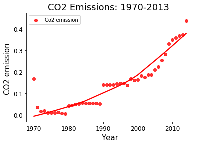

```python
# india_values
plot_CO2_emission(feature=np.array(cambodia_values),years=np.array(b),col = 'red')
```

Emmision increases and then gets stable for few years and then again on rise

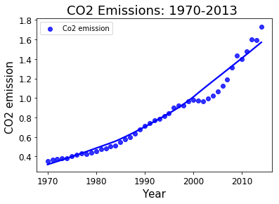

```python
plot_CO2_emission(feature=np.array(india_values),years=np.array(b),col = 'blue')
```

Trend in Increase in Emission level in India

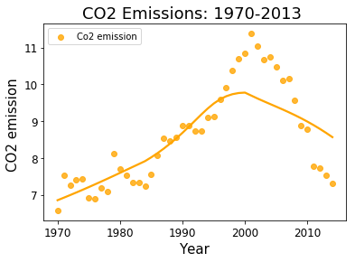

```python
plot_CO2_emission(feature=np.array(ireland_values),years=np.array(b),col = 'orange')
```

There has been decrease in Co2 emmision level in Ireland

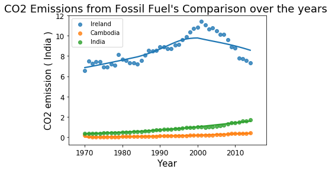

```python
plot_CO2_emission_all(np.array(b),ireland_values,'Ireland')
plot_CO2_emission_all(np.array(b),cambodia_values,'Cambodia')
plot_CO2_emission_all(np.array(b),india_values,'India')
```

Emmision of Co2 by different countries in years india emission is low as comparison to ireland but it is increasing whereas in ireland it is decreasing

```python
countries = np.array(co2.iloc[:,1])
```

```python
len(countries)
```

```
264
```

```python
countries_emmision = []
for i in range(len(countries)):
    tmp = np.array(co2.iloc[i,2:])
    countries_emmision.append(tmp.mean())
```

```python
def plot_CO2_emission_2(feature,countries_,col='blue'):
    plt.figure(num=None, figsize=(40,6),dpi = 100, facecolor='w', edgecolor='k')
#     sns.regplot(x=countries_, y=feature,color='orange', lowess=True,label="Co2 emission")
    plt.plot(countries_,feature,color = col)
#     plt.annotate(feature)
    plt.title("CO2 Emissions: 1970-2013 ", size=18)
    plt.ylabel("CO2 emission ", size=15)
    plt.xlabel("Countries", size=15)
    plt.xticks(size=12, rotation='vertical')
    plt.yticks(size=12)
    plt.legend(['Co2 Emission'])
```

```python
countries_clear_2 = []
countries_emmision_clear_2 = []
for i in range(len(countries_emmision)):
    if(np.isnan(countries_emmision[i]) == False):
        countries_clear_2.append(countries[i])
        countries_emmision_clear_2.append(countries_emmision[i])
```

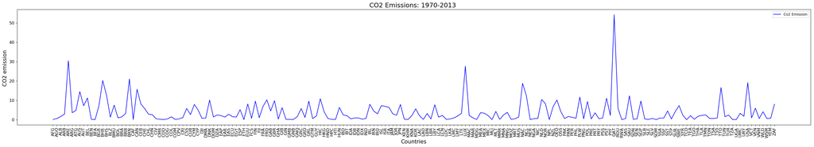

```python
plot_CO2_emission_2(feature=np.array(countries_emmision_clear_2),countries_=np.array(countries_clear_2))
```

```python
data = np.array(countries_emmision_clear_2)
print ("Observations of C02 Emmision among different Countries")
print ("Mean of CO2 " + str(data.mean()))
print ("Variance of CO2 " + str(data.var()))
print ("Standard Deviation of CO2 " + str(data.std()))
```

```
Observations of C02 Emmision among different Countries
Mean of CO2 4.135514541776172
Variance of CO2 38.58275043767678
Standard Deviation of CO2 6.211501464032411
```

# Fossil Fuels

Unit million metric tons of carbon

```python
df = pd.read_csv('Fossil-fuel co2 Global Estimates (1751-2013).csv')
```

```python
df.tail()
```

|  | Year | Total | Gas | Liquids | Solids | Production | Flaring | Capita |
| --- | --- | --- | --- | --- | --- | --- | --- | --- |
| 258 | 2009 | 8641 | 1580 | 3065 | 3517 | 415 | 64 | 1.26 |
| 259 | 2010 | 9137 | 1700 | 3129 | 3795 | 448 | 66 | 1.32 |
| 260 | 2011 | 9508 | 1762 | 3158 | 4027 | 496 | 64 | 1.36 |
| 261 | 2012 | 9671 | 1787 | 3214 | 4086 | 520 | 65 | 1.36 |
| 262 | 2013 | 9776 | 1806 | 3216 | 4131 | 554 | 68 | 1.36 |

Data snapshot of dataset used

```python
def plot_CO2_emission(feature1,feature2,name,col='blue'):
    sns.regplot(x=feature1, y=feature2,color=col ,lowess=True,label=name)
#     plt.title("CO2 Emissions from Fossil Fuel's via Cement Manufacture, and Gas Flaring: 1751-2013 ", size=18)
    plt.ylabel("CO2 emission ( "+name+" )", size=17)
    plt.xlabel("Year", size=17)
    plt.xticks(size=13)
    plt.yticks(size=13)
    print ("Mean of CO2 " + str(feature2.mean()))
    print ("Variance of CO2 " + str(feature2.var()))
    print ("Standard Deviation of CO2 " + str(feature2.std()))
    plt.legend()
    plt.show()
```

```python
def plot_CO2_emission_all(feature1,feature2,name):
    sns.regplot(x=feature1, y=feature2,lowess=True,label=name)
    plt.title("CO2 Emissions from Fossil Fuel's Comparison over the years ", size=18)
    plt.ylabel("CO2 emission ( "+name+" )", size=15)
    plt.xlabel("Year", size=15)
    plt.xticks(size=12)
    plt.yticks(size=12)
    plt.legend()
```

```
Mean of CO2 708.4600760456274
Variance of CO2 856818.7302702229
Standard Deviation of CO2 925.6450347029486
```

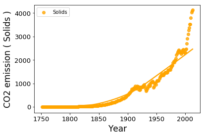

```python
plot_CO2_emission(df.Year,df.Solids,'Solids','orange')
```

```
Mean of CO2 202.92015209125475
Variance of CO2 183397.89818012947
Standard Deviation of CO2 428.2498081495536
```

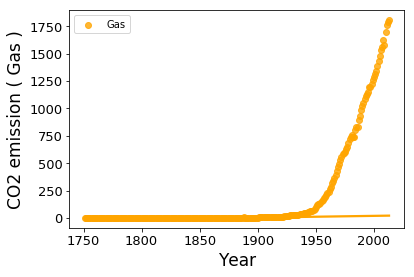

```python
plot_CO2_emission(df.Year,df.Gas,'Gas','orange')
```

```
Mean of CO2 526.6045627376426
Variance of CO2 945568.5300554379
Standard Deviation of CO2 972.4034811000205
```

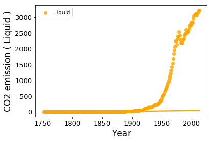

```python
plot_CO2_emission(df.Year,df.Liquids,'Liquid','orange')
```

```
Mean of CO2 39.741444866920155
Variance of CO2 8868.513046759357
Standard Deviation of CO2 94.1727829405044
```

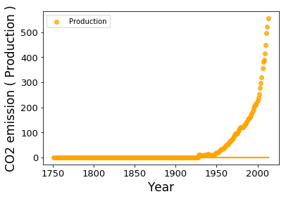

```python
plot_CO2_emission(df.Year,df.Production,'Production','orange')
```

```
Mean of CO2 13.752851711026617
Variance of CO2 721.0341044321245
Standard Deviation of CO2 26.85207821439757
```

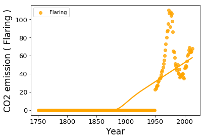

```python
plot_CO2_emission(df.Year,df.Flaring,'Flaring','orange')
```

```
Mean of CO2 1.0643749999999998
Variance of CO2 0.03319007936507937
Standard Deviation of CO2 0.18218144627013852
```

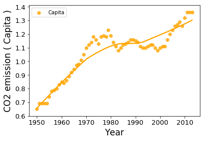

```python
plot_CO2_emission(df.Year,df.Capita,'Capita','orange')
```

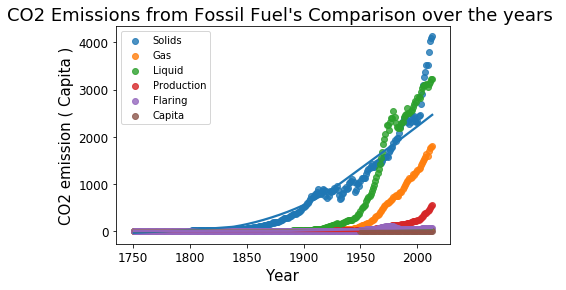

```python
plot_CO2_emission_all(df.Year,df.Solids,'Solids')
plot_CO2_emission_all(df.Year,df.Gas,'Gas')
plot_CO2_emission_all(df.Year,df.Liquids,'Liquid')
plot_CO2_emission_all(df.Year,df.Production,'Production')
plot_CO2_emission_all(df.Year,df.Flaring,'Flaring')
plot_CO2_emission_all(df.Year,df.Capita,'Capita')
```

As per the comparison the rate of emission of Solids is more than any other followed by Liquid.

```python
df.keys()
```

```
Index(['Year', 'Total', 'Gas', 'Liquids', 'Solids', 'Production', 'Flaring',
       'Capita'],
      dtype='object')
```

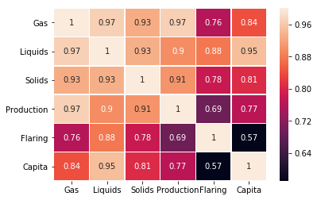

```python
sns.heatmap(df.drop(['Year','Total'],axis=1).corr(),linecolor='white',linewidths=0.4,annot=True)
```

As we can see from multiple plots the trends in climate change and increase in level's of carbon dioxide in our surrounding over the years span.